# Part 2 - Siemese Network - Final

```python
!python -V
```

```
Python 3.8.8
```

```python
import numpy as np
import cv2 as cv
import matplotlib.pyplot as plt
from zipfile import ZipFile
```

```python
path_for_project="D:\\Work_folders\\datasets\\Advanced Computer Vision Project"
```

```python
file_name = path_for_project + "\\Part 3 - Aligned Face Dataset from Pinterest.zip"
myfile=ZipFile(file_name,'r')


myfile.extractall()
myfile.close()
```

[output not shown]

**Please Note** At the time of my doing this project, there were some serious problems with dataset that was later rectified with the data. The archive was corrupt so had to extract outside the situations here.

```python
from pathlib import Path
p=Path(path_for_project)
p_data=p/"PINS"
```

```python
p_data.iterdir()
```

```
<generator object Path.iterdir at 0x0000016C12506190>
```

```python
print([x for x in p.iterdir() if x.is_dir()])
```

```
[WindowsPath('D:/Work_folders/datasets/Advanced Computer Vision Project/Part 2 Test Images'), WindowsPath('D:/Work_folders/datasets/Advanced Computer Vision Project/PINS')]
```

```python
labels=[]
for x in p_data.iterdir():
    x=str(x)
    if x!="PINS":
        labels.append(x.split("_")[-1])
    #print(x.split("\\")[-1])
```

```python
labels=labels[1:]
```

```python
labels
```

```
['Aaron Paul',
 'alexandra daddario',
 'Alvaro Morte',
 'alycia debnam carey face',
 'Amanda Crew',
 'Amaury Nolasco',
 'amber heard face',
 'Anna Gunn',
 'anne hathaway',
 'barbara palvin face',
 'bellamy blake face',
 'Benedict Cumberbatch',
 'Betsy Brandt',
 'bill gates',
 'Brenton Thwaites',
 'brie larson',
 'Brit Marling',
 'Bryan Cranston',
 'Caity Lotz',
 'Cameron Monaghan',
 'chadwick boseman face',
 'Chance Perdomo',
 'Chris Evans',
 'Chris Pratt',
 'Cobie Smulders',
 'Danielle Panabaker',
 'Dave Franco',
 'david mazouz',
 'Dominic Purcell',
 'drake',
 'dua lipa face',
 'Dwayne Johnson',
 'eliza taylor',
 'elizabeth olsen face',
 'elon musk',
 'Emilia Clarke',
 'Emily Bett Rickards',
 'Emma Stone',
 'emma watson face',
 'gal gadot face',
```

[output cut: 43 more lines]

```
 'selena gomez',
 'shakira',
 'Sophie Turner',
 'Stephen Amell',
 'Sundar Pichai',
 'tati gabrielle',
 'taylor swift',
 'Thomas Middleditch',
 'Tom Cavanagh',
 'tom holland face',
 'Ursula Corbero',
 'Wentworth Miller',
 'Willa Holland',
 'William Fichtner',
 'zendaya']
```

```python
import random
random.seed(0)
import os
paths=[]
for each in os.listdir(p_data):
    print(each)
    for files in (p_data/each).iterdir():
        paths.append(str(files))
        print(files)
```

[output not shown]

[output cut: 10530 more lines]

[output not shown]

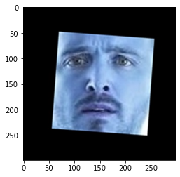

```python
temp_image=cv.imread(paths[10]) #checking if an image can be loaded
plt.imshow(temp_image)
```

```python
print(len(paths))
print(len(paths[1:]))
```

```
10486
10485
```

```python
paths=paths[1:]
random.shuffle(paths) # Shuffling images
```

```python
paths # WE have randomly shuffled paths or files which we can now use for further analysis
```

[output not shown]

[output cut: 946 more lines]

[output not shown]

```python
########################################################
#
########################################################
def remove_alpha_channel(data_img):
#Removing alpha channel from the images via Computer Vision Libraries
    for i in range(len(data_img)):
        #print(data_img[i].shape)
        try:
            assert data_img[i].shape[2]!=3
            #print("Before",i)
            #print(data_img[i])
            #print("After")
            data_img[i] = cv.cvtColor(data_img[i], cv.COLOR_BGRA2BGR)
            #print(data_img[i])
        except:
            pass
########################################################
#
########################################################
```

```python
for i in range(len(paths)):
    img=cv.imread(paths[i])
    try :
        #print(img.shape)
        if img.shape[2]!=3:
            try:
                print(img.shape)
                print(i)
            except:
                print(paths[i])
    except:
        print(paths[i])
```

Looks like all the images are of the same shape.

```python
from sklearn.preprocessing import LabelBinarizer
########################################################
#
########################################################
def generate_one_hot_encoding(classes,data_in,inverse=False):
    encoder = LabelBinarizer()
    encoder.fit(classes)
    if inverse:
        output=encoder.inverse_transform(data_in)
        return output
    else:
        transformed_labels=ecoder.transform(classes)
        return transfomed_labels
########################################################
#
########################################################
```

```python
len(labels)
```

```
98
```

```python
########################################################
#
########################################################
def _load_image(img_path):
    img = image.load_img(img_path, target_size=(224, 224))
    img = image.img_to_array(img)
    img = np.expand_dims(img, axis=0)
    img = preprocess_input(img)
    return img
########################################################
#
########################################################
```

**Loading the pre-built Keras Model**

```python
from keras.applications.vgg16 import VGG16
vgg16_weights = path_for_project + "\\Part 3 - vgg_face_weights.h5"
vgg16_model = VGG16(weights=vgg16_weights)
```

[output not shown]

[output cut: 16 more lines]

[output not shown]

**Note**: I have tried directly using the weights with the model in Keras. There are some serious errors popping up all the time. So, after much thought, it is abandoned. Looks like most of the problems are of compatibility issues and nothing else.

```python
from tensorflow.keras.models import Sequential
from tensorflow.keras.layers import ZeroPadding2D, Convolution2D, MaxPooling2D, Dropout, Flatten, Activation
from tensorflow.keras.models import Model
########################################################
#
########################################################
def vgg_face():
    model = Sequential()
    model.add(ZeroPadding2D((1,1),input_shape=(224,224, 3)))
    model.add(Convolution2D(64, (3, 3), activation='relu'))
    model.add(ZeroPadding2D((1,1)))
    model.add(Convolution2D(64, (3, 3), activation='relu'))
    model.add(MaxPooling2D((2,2), strides=(2,2)))

    model.add(ZeroPadding2D((1,1)))
    model.add(Convolution2D(128, (3, 3), activation='relu'))
    model.add(ZeroPadding2D((1,1)))
    model.add(Convolution2D(128, (3, 3), activation='relu'))
    model.add(MaxPooling2D((2,2), strides=(2,2)))

    model.add(ZeroPadding2D((1,1)))
    model.add(Convolution2D(256, (3, 3), activation='relu'))
    model.add(ZeroPadding2D((1,1)))
    model.add(Convolution2D(256, (3, 3), activation='relu'))
    model.add(ZeroPadding2D((1,1)))
    model.add(Convolution2D(256, (3, 3), activation='relu'))
    model.add(MaxPooling2D((2,2), strides=(2,2)))

    model.add(ZeroPadding2D((1,1)))
    model.add(Convolution2D(512, (3, 3), activation='relu'))
    model.add(ZeroPadding2D((1,1)))
    model.add(Convolution2D(512, (3, 3), activation='relu'))
    model.add(ZeroPadding2D((1,1)))
    model.add(Convolution2D(512, (3, 3), activation='relu'))
    model.add(MaxPooling2D((2,2), strides=(2,2)))

    model.add(ZeroPadding2D((1,1)))
    model.add(Convolution2D(512, (3, 3), activation='relu'))
    model.add(ZeroPadding2D((1,1)))
    model.add(Convolution2D(512, (3, 3), activation='relu'))
    model.add(ZeroPadding2D((1,1)))
    model.add(Convolution2D(512, (3, 3), activation='relu'))
    model.add(MaxPooling2D((2,2), strides=(2,2)))

    model.add(Convolution2D(4096, (7, 7), activation='relu'))
    model.add(Dropout(0.5))
    model.add(Convolution2D(4096, (1, 1), activation='relu'))
    model.add(Dropout(0.5))
    model.add(Convolution2D(2622, (1, 1)))
    model.add(Flatten())
    model.add(Activation('softmax'))
    return model
########################################################
#
########################################################

########################################################
#
########################################################

model = vgg_face()

model.load_weights(path_for_project + "\\Part 3 - vgg_face_weights.h5")
```

```python
vgg_face_descriptor = Model(inputs=model.layers[0].input, outputs=model.layers[-2].output)
```

**checking the Embedding vectors for a couple of images**

```python
# These are two non similar images
########################################################
img = cv.imread(paths[12])
img = (img / 255).astype(np.float32)
img = cv.resize(img, dsize = (224,224))
########################################################
img2 = cv.imread(paths[15])
img2 = (img2 / 255).astype(np.float32)
img2 = cv.resize(img2, dsize = (224,224))
########################################################

# These are two similar images
########################################################
img3 = cv.imread(paths[55])
img3 = (img3 / 255).astype(np.float32)
img3 = cv.resize(img3, dsize = (224,224))
########################################################
img4 = cv.imread(paths[59])
img4 = (img4 / 255).astype(np.float32)
img4 = cv.resize(img4, dsize = (224,224))
########################################################
```

```python
########################################################
# Distance metric for two embeddings
########################################################
def distance(emb1, emb2):
    return np.sum(np.square(emb1 - emb2))
########################################################
#
########################################################
```

```python
embedding_vector1 = vgg_face_descriptor.predict(np.expand_dims(img, axis=0))[0]
embedding_vector2 = vgg_face_descriptor.predict(np.expand_dims(img2, axis=0))[0]
embedding_vector3 = vgg_face_descriptor.predict(np.expand_dims(img3, axis=0))[0]
embedding_vector4 = vgg_face_descriptor.predict(np.expand_dims(img4, axis=0))[0]
```

```python
# Distance between two embedded Vectors.
print(distance(embedding_vector1,embedding_vector2))
print(distance(embedding_vector3,embedding_vector4))
```

```
0.53662354
0.25304538
```

Note here that the more the distance between two vectors, the more are distinct. So, we can notice here properly.

We could have used the "flow_from_directory" method, but it didn't feel right when we know that we are not going to use it with our classifier methods and makes it tough. So, the idea was abandoned here.

```python
########################################################
# Function to extract names and embeddings from the pathlib of images.
########################################################
def name_extractor(paths_given,model_given):
    labels=[]
    paths=paths_given
    model=model_given
    embeddings=[]
    for each in paths:
        img=cv.imread(each)
        img=cv.resize(img,dsize=(224,224))
        try:
            embeddings.append(model.predict(np.expand_dims(img,axis=0))[0])
        except:
            embeddings.append(np.zeros(1, 2622))
        #print(each)
        x=each.split("\\")
        #print("\n",x[-2])
        labels.append(x[-2])

    return labels,embeddings
########################################################
#
########################################################
```

```python
y,x=name_extractor(paths,model)
```

```python
x=np.array(x)
y=np.array(y)
print(x.shape)

print(y.shape)
```

```
(10485, 2622)
(10485,)
```

```
pins_Dwayne Johnson
```

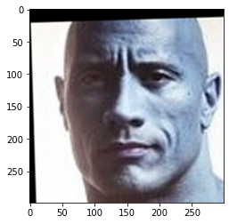

```python
plt.imshow(cv.imread(paths[125]))
print(y[125])
```

```python
from sklearn.svm import SVC
########################################################
# Conditioning the image before passing it to classifier
########################################################
def train_conditioning(x_train):
    from sklearn.preprocessing import StandardScaler
    from sklearn.decomposition import PCA
    ########################################################
    ########################################################
    x=x_train
    scaler=StandardScaler()
    components=PCA()
    x=scaler.fit_transform(x)
    x=components.fit_transform(x)
    print(x.shape)
    return x
########################################################
#
########################################################
svc_classifier=SVC()
svc_classifier.fit(train_conditioning(x),y)
```

```
(10485, 2622)
```

```
SVC()
```

```python
i1=cv.imread(paths[1])
i2=cv.imread(paths[2])
i1=np.expand_dims(cv.resize(i1,dsize=(224,224)),axis=0)
i2=np.expand_dims(cv.resize(i2,dsize=(224,224)),axis=0)
```

```python
########################################################
#
########################################################
def give_prediction(embedding_model,classification_model,test_data):
    data1=embedding_model.predict(test_data)
    #data1=train_conditioning(data1)
    #print(data1.shape)
    data1=classification_model.predict(data1)
    return data1
########################################################
#
########################################################
```

```python
output=give_prediction(vgg_face_descriptor,svc_classifier,i1)
#prediction=generate_one_hot_encoding_inverse(output)
output2=give_prediction(vgg_face_descriptor,svc_classifier,i2)
```

```
The prediction is :  ['pins_Gwyneth Paltrow']
```

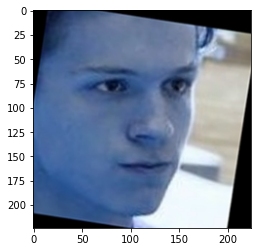

```python
plt.imshow(i1[0])
print("The prediction is : ",output)
```

```
The prediction is :  ['pins_Gwyneth Paltrow']
```

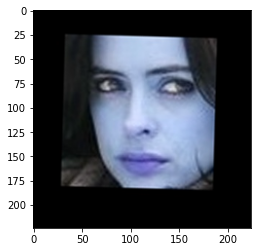

```python
plt.imshow(i2[0])
print("The prediction is : ",output2)
```

```python
test_1=cv.resize(cv.imread(path_for_project + "\\Part 2 Test Images\\Part_2_-_Test_Image_-_Dwayne_Johnson4.jpg"),dsize=(224,224))
test_2=cv.resize(cv.imread(path_for_project + "\\Part 2 Test Images\\Part_2-_Test_Image_-_Benedict_Cumberbatch9.jpg"),dsize=(224,224))
```

```python
output3=give_prediction(vgg_face_descriptor,svc_classifier,np.expand_dims(test_1,axis=0))
#prediction=generate_one_hot_encoding_inverse(output)
output4=give_prediction(vgg_face_descriptor,svc_classifier,np.expand_dims(test_2,axis=0))
```

```
The Prediction is : ['pins_Gwyneth Paltrow']
```

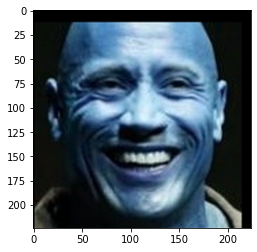

```python
plt.imshow(test_1)
print("The Prediction is :",output3)
```

```
The Prediction is : ['pins_Gwyneth Paltrow']
```

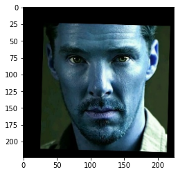

```python
plt.imshow(test_2)
print("The Prediction is :",output4)
```

```python
from sklearn.neighbors import KNeighborsClassifier as knn
knn_classifier=knn()
knn_classifier.fit(train_conditioning(x),y)

output=give_prediction(vgg_face_descriptor,knn_classifier,i1)
#prediction=generate_one_hot_encoding_inverse(output)
output2=give_prediction(vgg_face_descriptor,knn_classifier,i2)

output3=give_prediction(vgg_face_descriptor,knn_classifier,np.expand_dims(test_1,axis=0))
#prediction=generate_one_hot_encoding_inverse(output)
output4=give_prediction(vgg_face_descriptor,knn_classifier,np.expand_dims(test_2,axis=0))
```

```
(10485, 2622)
```

```python
print("Predictions made by KNN Classifier")
print(output)
print(output2)
print(output3)
print(output4)
```

```
Predictions made by KNN Classifier
['pins_Josh Radnor']
['pins_Josh Radnor']
['pins_Brit Marling']
['pins_barbara palvin face']
```

```python
from tensorflow.keras.models import Sequential, Model
from tensorflow.keras.layers import Input, Conv2D, MaxPooling2D, Flatten, Dense, Lambda
from tensorflow.keras import backend as K
input_shape=(224,224,3)
left_input = Input(input_shape)
right_input = Input(input_shape)
model = Sequential()
#model.add(Conv2D(64, (10,10), activation='relu', input_shape=input_shape))
#model.add(MaxPooling2D())
#model.add(Conv2D(128, (7,7), activation='relu'))
#model.add(MaxPooling2D())
model.add(vgg_face_descriptor)
encoded_l = model(left_input)
encoded_r = model(right_input)
L1_layer = Lambda(lambda tensors:K.abs(tensors[0] - tensors[1]))
L1_distance = L1_layer([encoded_l, encoded_r])
prediction = Dense(98,activation='sigmoid')(L1_distance)
prediction = Dense(1,activation='sigmoid')(L1_distance)
siamese_net = Model(inputs=[left_input,right_input],outputs=prediction)
```

```python
siamese_net.summary()
```

```
Model: "functional_3"
__________________________________________________________________________________________________
Layer (type)                    Output Shape         Param #     Connected to
==================================================================================================
input_1 (InputLayer)            [(None, 224, 224, 3) 0
__________________________________________________________________________________________________
input_2 (InputLayer)            [(None, 224, 224, 3) 0
__________________________________________________________________________________________________
sequential_1 (Sequential)       (None, 2622)         145002878   input_1[0][0]
                                                                 input_2[0][0]
__________________________________________________________________________________________________
lambda (Lambda)                 (None, 2622)         0           sequential_1[0][0]
                                                                 sequential_1[1][0]
__________________________________________________________________________________________________
dense_1 (Dense)                 (None, 1)            2623        lambda[0][0]
==================================================================================================
Total params: 145,005,501
Trainable params: 145,005,501
Non-trainable params: 0
__________________________________________________________________________________________________
```

```python
input_data=[i1,i2]
out=siamese_net.predict(input_data)
```

```python
print("The probability of their match is :", out[0][0])
```

```
The probability of their match is : 0.03353846
```

```python
print("index in the paths for similar pictures")
for each in range(len(paths)):
    try:
        assert "Dwayne" in paths[each]
        print(each)
    except:
        pass
```

```
index in the paths for similar pictures
55
59
125
143
204
264
290
335
336
356
376
399
493
568
669
734
757
824
1092
1405
1665
1679
1753
1838
1853
2108
2298
2306
2411
2569
2594
2641
2676
2685
2731
2768
2827
3030
3112
```

[output cut: 70 more lines]

```
8526
8562
8659
8980
9395
9538
9607
9683
9720
9918
10073
10096
10214
10328
10380
```

```python
i3=cv.imread(paths[55])
i4=cv.imread(paths[59])
```

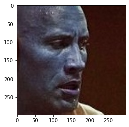

```python
plt.imshow(i3)
```

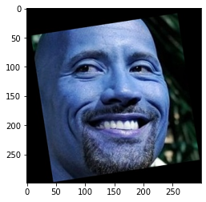

```python
plt.imshow(i4)
```

```python
i3=np.expand_dims(cv.resize(i3,dsize=(224,224)),axis=0)
i4=np.expand_dims(cv.resize(i4,dsize=(224,224)),axis=0)
input_data2=[i3,i4]
out2=siamese_net.predict(input_data2)
print("The probability of their match is :", out2[0][0])
```

```
The probability of their match is : 0.9478083
```